# Chapter 2 - Time Series Graphics

6. Use the following graphics functions: `autoplot()`, `ggseasonplot()`, `ggsubseriesplot()` , `gglagplot()`, `ggAcf()` and explore features from the `hsales` series.
- Can you spot any seasonality, cyclicity and trend? -What do you learn about the series?

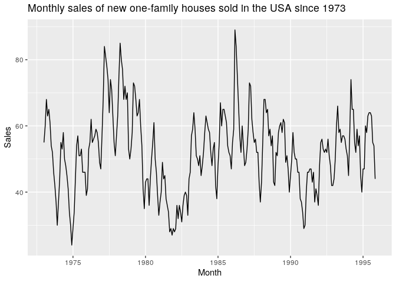

```r
hsales %>%
  autoplot() +
  labs(
    x = 'Month',
    y = 'Sales',
    title = 'Monthly sales of new one-family houses sold in the USA since 1973'
  )
```

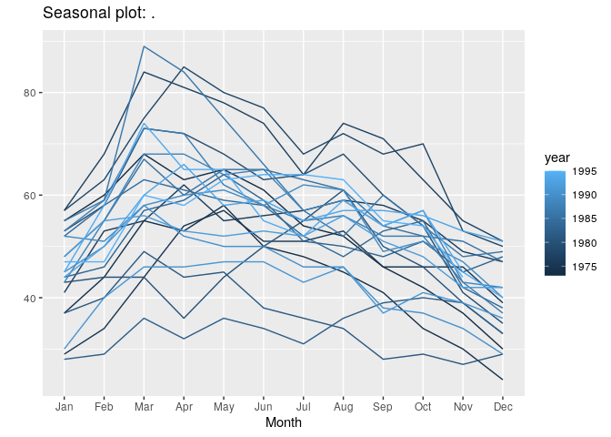

```r
hsales %>% ggseasonplot(continuous = TRUE)
```

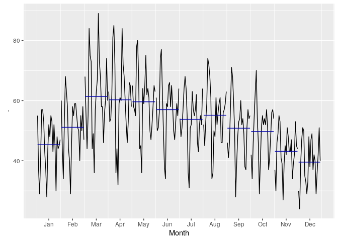

```r
hsales %>% ggsubseriesplot()
```

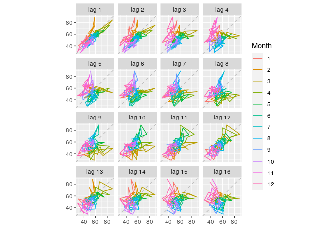

```r
hsales %>% window(start = 1984) %>% gglagplot()
```

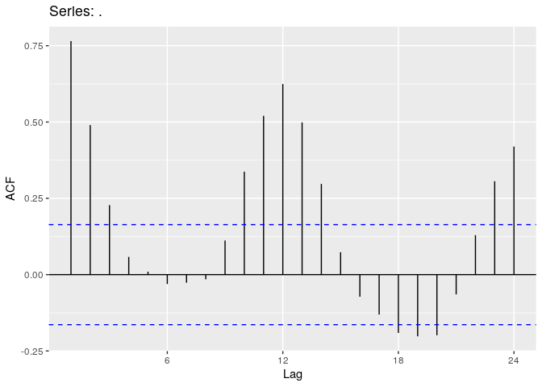

```r
hsales %>% window(start = 1984) %>% ggAcf()
```

We can see a seasonality of 12 months via the lag and ACF plots, with the peak coming in Mar/April/May.

7. **Skipped**
8. **The following time plots and ACF plots correspond to four di erent time series. Your task is to match each time plot in the rst row with one of the ACF plots in the second row.**
- 1 -> B
- 2 -> A
- 3 -> D
- 4 -> C
9. **The `pigs` data shows the monthly total number of pigs slaughtered in Victoria, Australia, from Jan 1980 to Aug 1995. Use `mypigs <- window(pigs, start=1990)` to select the data starting from 1990. Use `autoplot()` and `ggAcf() for`mypigs` series and compare these to white noise plots.**

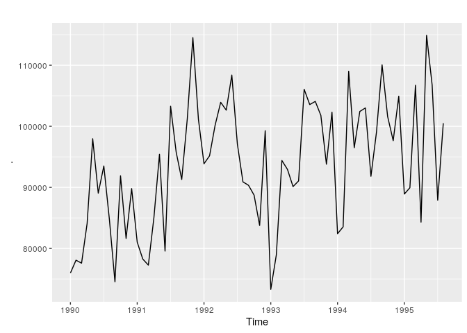

```r
fma::pigs %>% window(start = 1990) %>% autoplot()
```

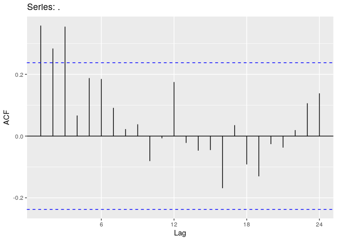

```r
fma::pigs %>% window(start = 1990) %>% ggAcf()
```

10. **dj contains 292 consecutive trading days of the Dow Jones Index. Do the changes in the Dow Jones Index look like white noise?**

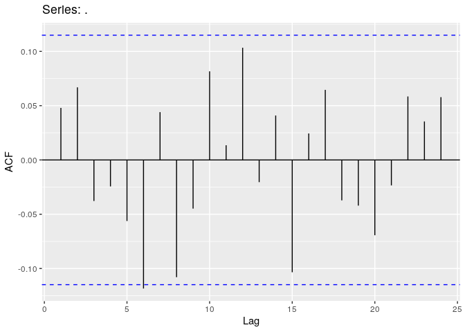

```r
dj %>% diff() %>% ggAcf()
```

The changes in the Dow Jones index do look like white noise.